# Speech Assignment 1b 20d070009 Amruta Mahendra Parulekar

# Impulse Train

120 Hz:

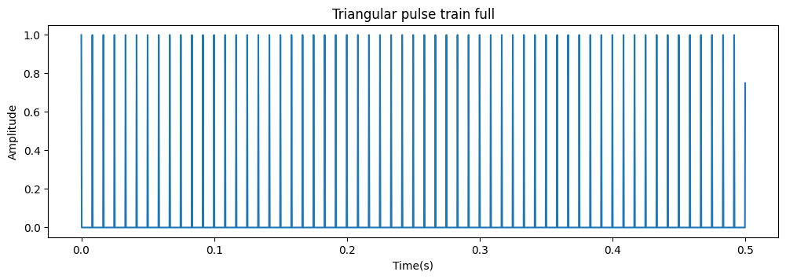

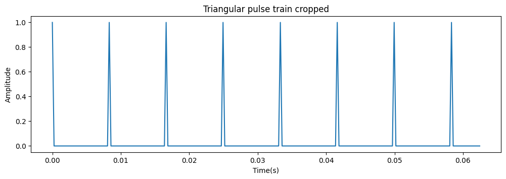

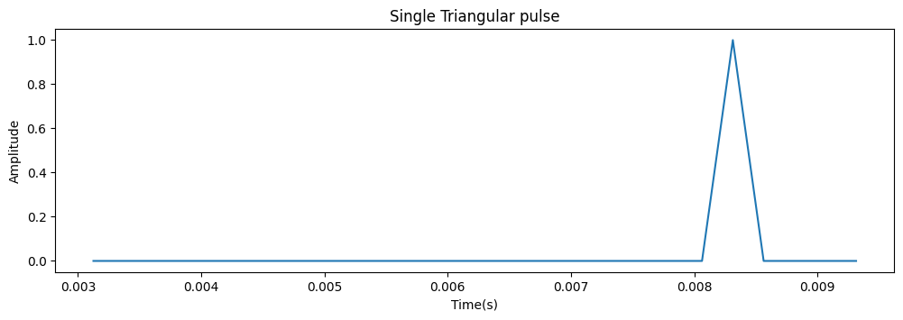

```python
#importing libraries
import scipy.signal as signal
from IPython.display import Audio, display
import numpy as np
import matplotlib.pyplot as plt
arr=[]
for i in range(60):
  arr.append(int(i*133.33))
#Generating a triangular pulse for 60 samples in an array of 8000 samples, so when sampling rate is 16000 Hz, the signal frequency will be 120 Hz
#imp120 = signal.unit_impulse(8000, arr)
#plotting on the time axis, for sampling rate 16000, there will be 10000 samples in 0.625 seconds
t=np.linspace(0,0.5,8000)
imp120=np.zeros(8000)
for i in range (8000):
  if i in arr:
      imp120[i]=1
      imp120[i-3]=1/4
      imp120[i-2]=1/2
      imp120[i-1]=3/4
      imp120[i+3]=1/4
      imp120[i+2]=1/2
      imp120[i+1]=3/4

plt.plot(t, imp120)
#labelling graph
plt.xlabel('Time(s)')
plt.ylabel('Amplitude')
plt.title('Triangular pulse train full')
plt.show()
plt.plot(t[:1000], imp120[:1000])
plt.xlabel('Time(s)')
plt.ylabel('Amplitude')
plt.title('Triangular pulse train cropped')
plt.show()
plt.plot(t[50:150], imp120[50:150])
plt.xlabel('Time(s)')
plt.ylabel('Amplitude')
plt.title('Single Triangular pulse')
plt.show()
```

220 Hz:

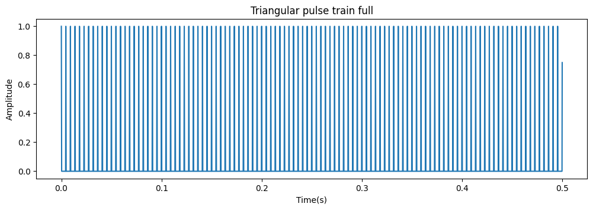

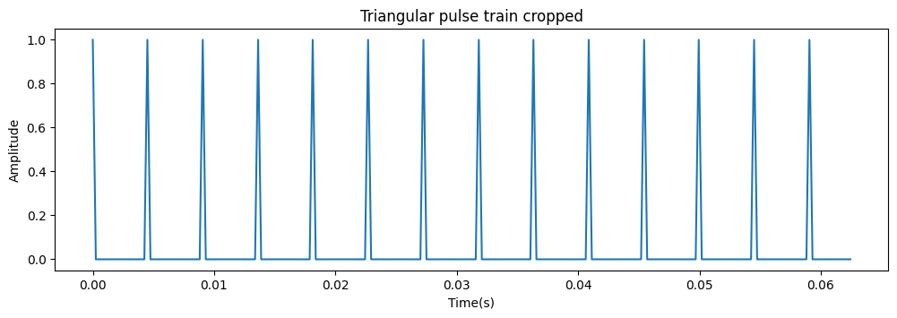

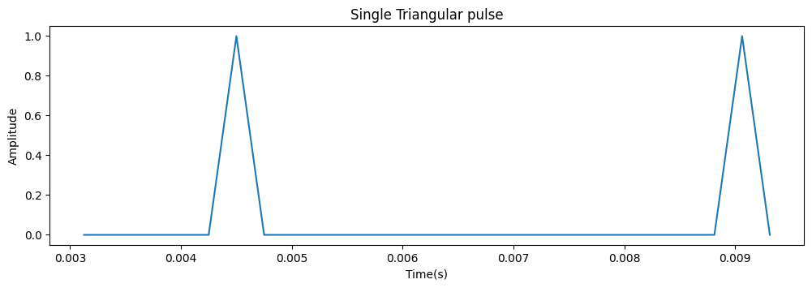

```python
#importing libraries
import scipy.signal as signal
from IPython.display import Audio, display

arr=[]
for i in range(110):
  arr.append(int(i*72.72))
#Generating a triangular pulse for 110 samples in an array of 8000 samples, so when sampling rate is 16000 Hz, the signal frequency will be 120 Hz
#imp220 = signal.unit_impulse(8000, arr)
#plotting on the time axis, for sampling rate 16000, there will be 10000 samples in 0.625 seconds
t=np.linspace(0,0.5,8000)
imp220=np.zeros(8000)
for i in range (8000):
  if i in arr:
      imp220[i]=1
      imp220[i-3]=1/4
      imp220[i-2]=1/2
      imp220[i-1]=3/4
      imp220[i+3]=1/4
      imp220[i+2]=1/2
      imp220[i+1]=3/4
plt.plot(t, imp220)
#labelling graph
plt.xlabel('Time(s)')
plt.ylabel('Amplitude')
plt.title('Triangular pulse train full')
plt.show()
plt.plot(t[:1000], imp220[:1000])
plt.xlabel('Time(s)')
plt.ylabel('Amplitude')
plt.title('Triangular pulse train cropped')
plt.show()
plt.plot(t[50:150], imp220[50:150])
plt.xlabel('Time(s)')
plt.ylabel('Amplitude')
plt.title('Single Triangular pulse')
plt.show()
```

# Vowel /u/

```python
#importing libraries
import scipy
import math
from scipy import signal
import numpy as np
import matplotlib.pyplot as plt
from scipy.io.wavfile import write

#assigning values
f1=300.0
f2=870.0
f3=2240.0
b1=100.0
fs=16000.0
ts=1.0/fs

#calculating coefficients of transfer function
r=pow(math.e,-1*math.pi*b1*ts)
theta1=2*math.pi*f1*ts
theta2=2*math.pi*f2*ts
theta3=2*math.pi*f3*ts
z=[0,0,0,0,0,0]
p=[r*pow(math.e,1j*theta1), r*pow(math.e,-1*1j*theta1), r*pow(math.e,1j*theta2),r*pow(math.e,-1*1j*theta2),r*pow(math.e,1j*theta3),r*pow(math.e,-1*1j*theta3) ]
a,b=scipy.signal.zpk2tf(z, p, 1)
print(a)
print(b)
```

```
[1. 0. 0. 0. 0. 0. 0.]
[  1.          -5.04534821  11.22737737 -14.20053893  10.79502409
  -4.6642491    0.88886517]
```

Formants:

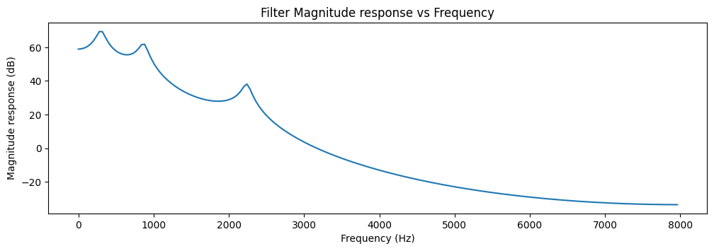

```python
#transfer function as a discrete linear time invariant system
system = signal.dlti(a, b, dt=0.0000625)
#magnitude response vs frequency
freq, resp= signal.dlti.freqresp(system,n=200)
#scaling axes (Y axis in decibel and x axis using sampling frequency)
plt.plot(16000*freq/(2*math.pi),20*np.log10(np.abs(resp)))
#labelling graph
plt.xlabel('Frequency (Hz)')
plt.ylabel('Magnitude response (dB)')
plt.title('Filter Magnitude response vs Frequency')
```

120 Hz:

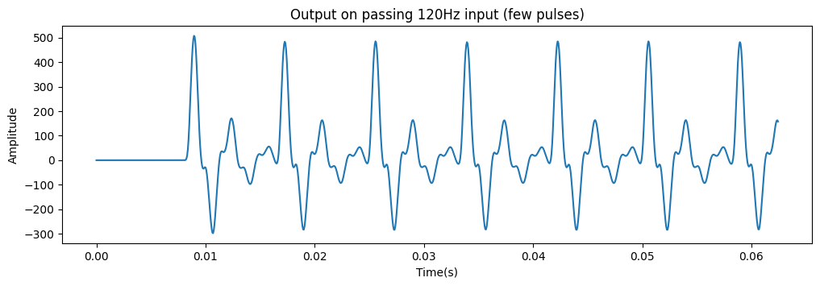

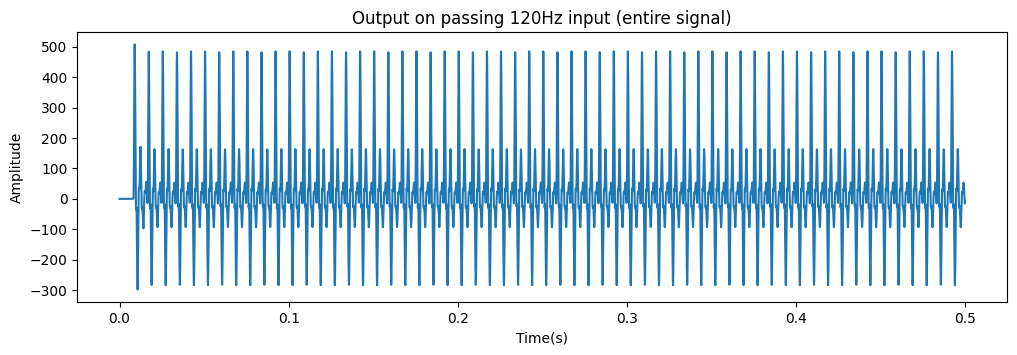

```python
out120=np.zeros_like(imp120)
for i in range(8000):
  if (i==0 or i==1 or i==2 or i==3 or i==4 or i==5):
    out120[i]=0
  else:
    out120[i]=(imp120[i]-b[1]*out120[i-1]-b[2]*out120[i-2]-b[3]*out120[i-3]-b[4]*out120[i-4]-b[5]*out120[i-5]-b[6]*out120[i-6])

    #plotting the output of the filter
t=np.linspace(0,0.5,8000)
plt.plot(t[:1000], out120[:1000])
plt.xlabel('Time(s)')
plt.ylabel('Amplitude')
plt.title('Output on passing 120Hz input (few pulses)')
plt.show()
plt.plot(t, out120)
plt.xlabel('Time(s)')
plt.ylabel('Amplitude')
plt.title('Output on passing 120Hz input (entire signal)')
plt.show()
```

```python
#Conversion to audio
Audio(np.asfarray(out120),rate=16000)
```

[interactive chart not shown]

220 Hz:

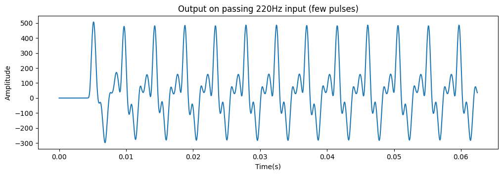

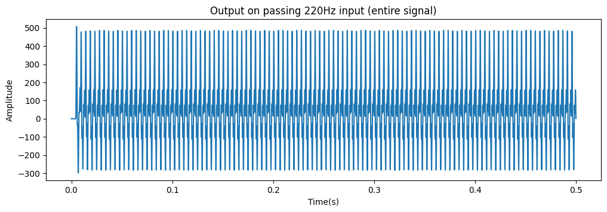

```python
out220=np.zeros_like(imp120)
for i in range(8000):
  if (i==0 or i==1 or i==2 or i==3 or i==4 or i==5):
    out220[i]=0
  else:
    out220[i]=(imp220[i]-b[1]*out220[i-1]-b[2]*out220[i-2]-b[3]*out220[i-3]-b[4]*out220[i-4]-b[5]*out220[i-5]-b[6]*out220[i-6])

    #plotting the output of the filter
t=np.linspace(0,0.5,8000)
plt.plot(t[:1000], out220[:1000])
plt.xlabel('Time(s)')
plt.ylabel('Amplitude')
plt.title('Output on passing 220Hz input (few pulses)')
plt.show()
plt.plot(t, out220)
plt.xlabel('Time(s)')
plt.ylabel('Amplitude')
plt.title('Output on passing 220Hz input (entire signal)')
plt.show()
```

```python
#Conversion to audio
Audio(np.asfarray(out220),rate=16000)
```

[interactive chart not shown]

# Hamming window

5ms:

--120Hz

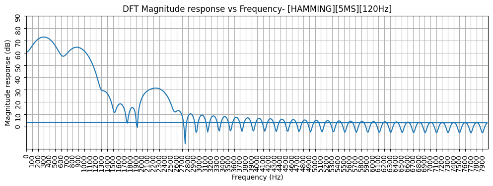

```python
samples=int(0.005*16000)
win=out120[10*samples:11*samples]*np.hamming(samples)
dft=np.fft.fft(win,1024)
freq=np.fft.fftfreq(dft.shape[-1],0.0000625)

#scaling axes (Y axis in decibel and x axis using sampling frequency)
plt.rcParams["figure.figsize"] = [12, 3.50]
plt.plot(freq,20*np.log10(np.abs(dft)))
#labelling graph
plt.xlabel('Frequency (Hz)')
plt.ylabel('Magnitude response (dB)')
plt.title('DFT Magnitude response vs Frequency- [HAMMING][5MS][120Hz]')
plt.xlim(0,8000)
plt.xticks(np.arange(0,8000,100),rotation='vertical')
plt.yticks(np.arange(0,100,10),rotation='vertical')
plt.grid("True")
```

--220Hz

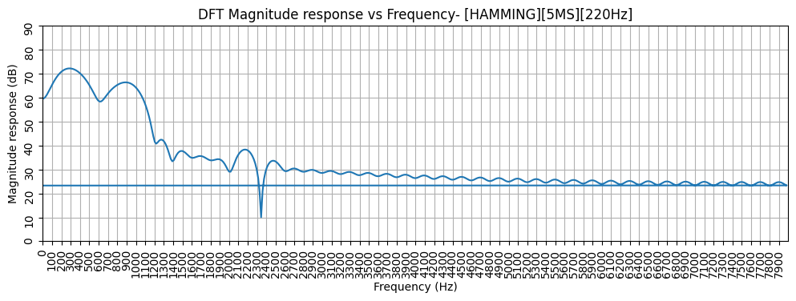

```python
samples=int(0.005*16000)
win=out220[10*samples:11*samples]*np.hamming(samples)
dft=np.fft.fft(win,1024)
freq=np.fft.fftfreq(dft.shape[-1],0.0000625)

#scaling axes (Y axis in decibel and x axis using sampling frequency)
plt.plot(freq,20*np.log10(np.abs(dft)))
#labelling graph
plt.xlabel('Frequency (Hz)')
plt.ylabel('Magnitude response (dB)')
plt.title('DFT Magnitude response vs Frequency- [HAMMING][5MS][220Hz]')
plt.xlim(0,8000)
plt.xticks(np.arange(0,8000,100),rotation='vertical')
plt.yticks(np.arange(0,100,10),rotation='vertical')
plt.grid("True")
```

10ms:

--120Hz

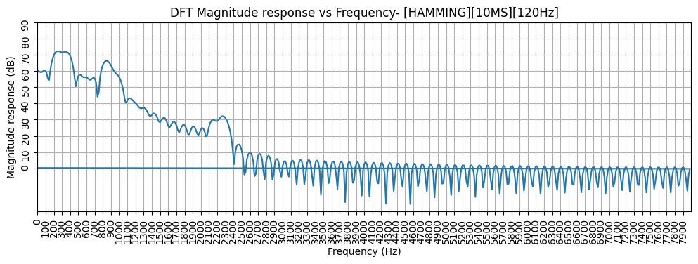

```python
samples=int(0.010*16000)
win=out120[10*samples:11*samples]*np.hamming(samples)
dft=np.fft.fft(win,1024)
freq=np.fft.fftfreq(dft.shape[-1],0.0000625)

#scaling axes (Y axis in decibel and x axis using sampling frequency)
plt.plot(freq,20*np.log10(np.abs(dft)))
#labelling graph
plt.xlabel('Frequency (Hz)')
plt.ylabel('Magnitude response (dB)')
plt.title('DFT Magnitude response vs Frequency- [HAMMING][10MS][120Hz]')
plt.xlim(0,8000)
plt.xticks(np.arange(0,8000,100),rotation='vertical')
plt.yticks(np.arange(0,100,10),rotation='vertical')
plt.grid("True")
```

--220Hz

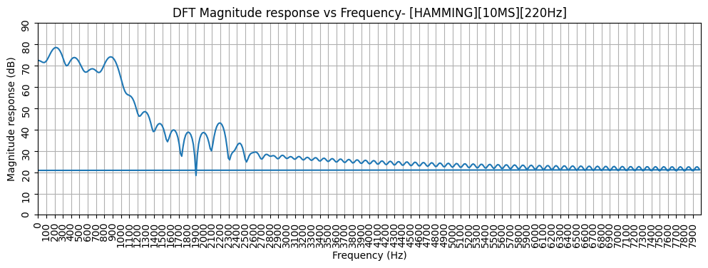

```python
samples=int(0.010*16000)
win=out220[10*samples:11*samples]*np.hamming(samples)
dft=np.fft.fft(win,1024)
freq=np.fft.fftfreq(dft.shape[-1],0.0000625)

#scaling axes (Y axis in decibel and x axis using sampling frequency)
plt.plot(freq,20*np.log10(np.abs(dft)))
#labelling graph
plt.xlabel('Frequency (Hz)')
plt.ylabel('Magnitude response (dB)')
plt.title('DFT Magnitude response vs Frequency- [HAMMING][10MS][220Hz]')
plt.xlim(0,8000)
plt.xticks(np.arange(0,8000,100),rotation='vertical')
plt.yticks(np.arange(0,100,10),rotation='vertical')
plt.grid("True")
```

20ms:

--120Hz

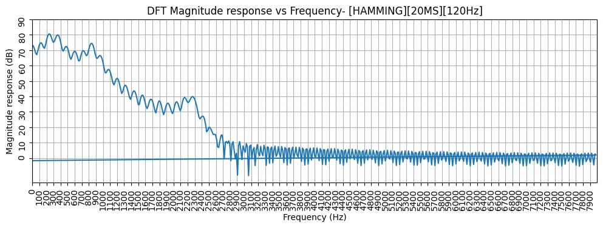

```python
samples=int(0.020*16000)
win=out120[10*samples:11*samples]*np.hamming(samples)
dft=np.fft.fft(win,1024)
freq=np.fft.fftfreq(dft.shape[-1],0.0000625)

#scaling axes (Y axis in decibel and x axis using sampling frequency)
plt.plot(freq,20*np.log10(np.abs(dft)))
#labelling graph
plt.xlabel('Frequency (Hz)')
plt.ylabel('Magnitude response (dB)')
plt.title('DFT Magnitude response vs Frequency- [HAMMING][20MS][120Hz]')
plt.xlim(0,8000)
plt.xticks(np.arange(0,8000,100),rotation='vertical')
plt.yticks(np.arange(0,100,10),rotation='vertical')
plt.grid("True")
```

--220Hz

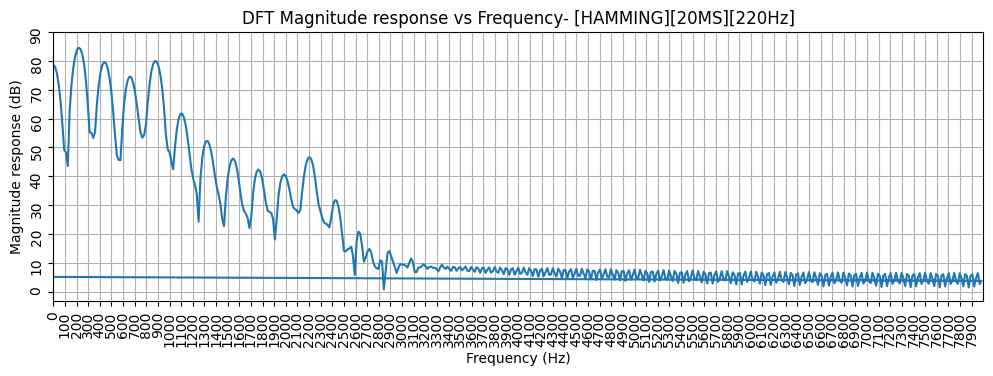

```python
samples=int(0.020*16000)
win=out220[10*samples:11*samples]*np.hamming(samples)
dft=np.fft.fft(win,1024)
freq=np.fft.fftfreq(dft.shape[-1],0.0000625)

#scaling axes (Y axis in decibel and x axis using sampling frequency)
plt.plot(freq,20*np.log10(np.abs(dft)))
#labelling graph
plt.xlabel('Frequency (Hz)')
plt.ylabel('Magnitude response (dB)')
plt.title('DFT Magnitude response vs Frequency- [HAMMING][20MS][220Hz]')
plt.xlim(0,8000)
plt.xticks(np.arange(0,8000,100),rotation='vertical')
plt.yticks(np.arange(0,100,10),rotation='vertical')
plt.grid("True")
```

40ms

--120Hz

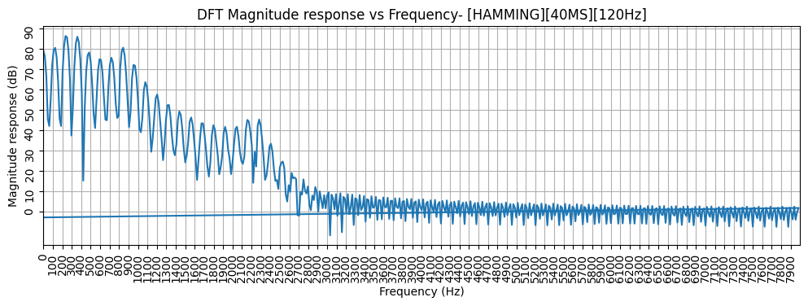

```python
samples=int(0.040*16000)
win=out120[10*samples:11*samples]*np.hamming(samples)
dft=np.fft.fft(win,1024)
freq=np.fft.fftfreq(dft.shape[-1],0.0000625)

#scaling axes (Y axis in decibel and x axis using sampling frequency)
plt.plot(freq,20*np.log10(np.abs(dft)))
#labelling graph
plt.xlabel('Frequency (Hz)')
plt.ylabel('Magnitude response (dB)')
plt.title('DFT Magnitude response vs Frequency- [HAMMING][40MS][120Hz]')
plt.xlim(0,8000)
plt.xticks(np.arange(0,8000,100),rotation='vertical')
plt.yticks(np.arange(0,100,10),rotation='vertical')
plt.grid("True")
```

--220Hz

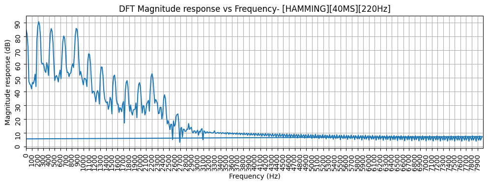

```python
samples=int(0.040*16000)
win=out220[10*samples:11*samples]*np.hamming(samples)
dft=np.fft.fft(win,1024)
freq=np.fft.fftfreq(dft.shape[-1],0.0000625)

#scaling axes (Y axis in decibel and x axis using sampling frequency)
plt.plot(freq,20*np.log10(np.abs(dft)))
#labelling graph
plt.xlabel('Frequency (Hz)')
plt.ylabel('Magnitude response (dB)')
plt.title('DFT Magnitude response vs Frequency- [HAMMING][40MS][220Hz]')
plt.xlim(0,8000)
plt.xticks(np.arange(0,8000,100),rotation='vertical')
plt.yticks(np.arange(0,100,10),rotation='vertical')
plt.grid("True")
```

# Rectangular window

5ms:

-- 120Hz

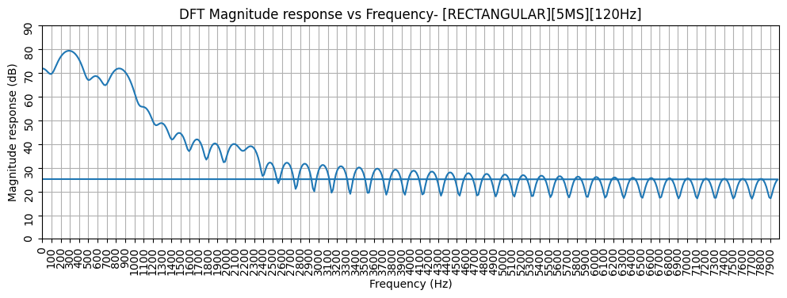

```python
samples=int(0.005*16000)
win=out120[10*samples:11*samples]
dft=np.fft.fft(win,1024)
freq=np.fft.fftfreq(dft.shape[-1],0.0000625)

#scaling axes (Y axis in decibel and x axis using sampling frequency)
plt.plot(freq,20*np.log10(np.abs(dft)))
#labelling graph
plt.xlabel('Frequency (Hz)')
plt.ylabel('Magnitude response (dB)')
plt.title('DFT Magnitude response vs Frequency- [RECTANGULAR][5MS][120Hz]')
plt.xlim(0,8000)
plt.xticks(np.arange(0,8000,100),rotation='vertical')
plt.yticks(np.arange(0,100,10),rotation='vertical')
plt.grid("True")
```

-- 220Hz

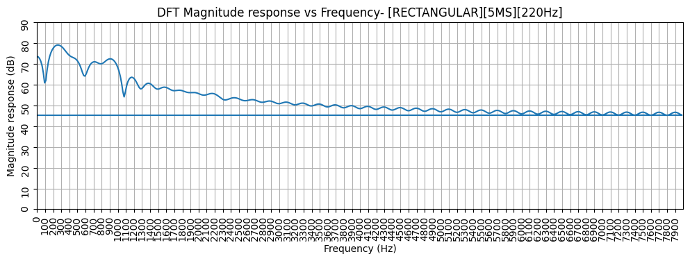

```python
samples=int(0.005*16000)
win=out220[10*samples:11*samples]
dft=np.fft.fft(win,1024)
freq=np.fft.fftfreq(dft.shape[-1],0.0000625)

#scaling axes (Y axis in decibel and x axis using sampling frequency)
plt.plot(freq,20*np.log10(np.abs(dft)))
#labelling graph
plt.xlabel('Frequency (Hz)')
plt.ylabel('Magnitude response (dB)')
plt.title('DFT Magnitude response vs Frequency- [RECTANGULAR][5MS][220Hz]')
plt.xlim(0,8000)
plt.xticks(np.arange(0,8000,100),rotation='vertical')
plt.yticks(np.arange(0,100,10),rotation='vertical')
plt.grid("True")
```

10ms:

--120 Hz

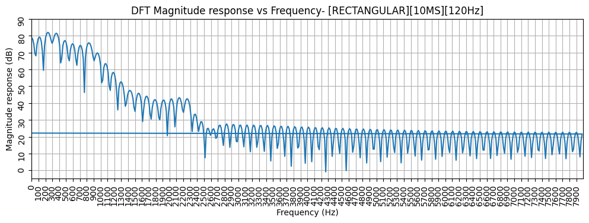

```python
samples=int(0.010*16000)
win=out120[10*samples:11*samples]
dft=np.fft.fft(win,1024)
freq=np.fft.fftfreq(dft.shape[-1],0.0000625)

#scaling axes (Y axis in decibel and x axis using sampling frequency)
plt.plot(freq,20*np.log10(np.abs(dft)))
#labelling graph
plt.xlabel('Frequency (Hz)')
plt.ylabel('Magnitude response (dB)')
plt.title('DFT Magnitude response vs Frequency- [RECTANGULAR][10MS][120Hz]')
plt.xlim(0,8000)
plt.xticks(np.arange(0,8000,100),rotation='vertical')
plt.yticks(np.arange(0,100,10),rotation='vertical')
plt.grid("True")
```

--220 Hz

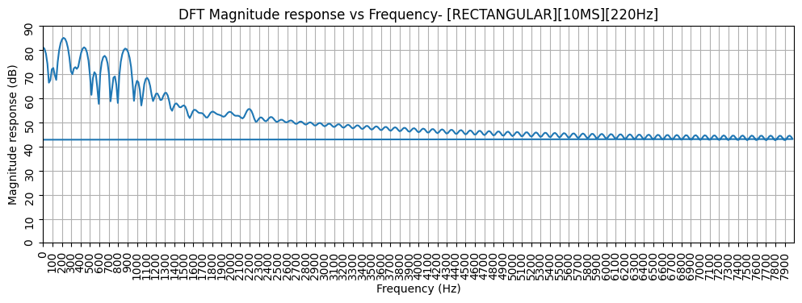

```python
samples=int(0.010*16000)
win=out220[10*samples:11*samples]
dft=np.fft.fft(win,1024)
freq=np.fft.fftfreq(dft.shape[-1],0.0000625)

#scaling axes (Y axis in decibel and x axis using sampling frequency)
plt.plot(freq,20*np.log10(np.abs(dft)))
#labelling graph
plt.xlabel('Frequency (Hz)')
plt.ylabel('Magnitude response (dB)')
plt.title('DFT Magnitude response vs Frequency- [RECTANGULAR][10MS][220Hz]')
plt.xlim(0,8000)
plt.xticks(np.arange(0,8000,100),rotation='vertical')
plt.yticks(np.arange(0,100,10),rotation='vertical')
plt.grid("True")
```

20ms:

--120Hz

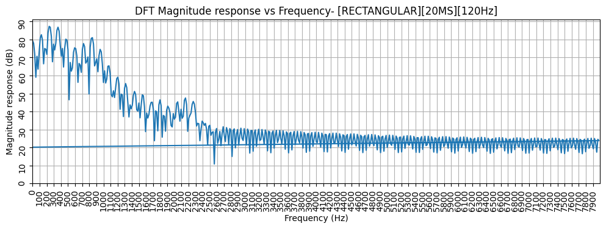

```python
samples=int(0.020*16000)
win=out120[10*samples:11*samples]
dft=np.fft.fft(win,1024)
freq=np.fft.fftfreq(dft.shape[-1],0.0000625)

#scaling axes (Y axis in decibel and x axis using sampling frequency)
plt.plot(freq,20*np.log10(np.abs(dft)))
#labelling graph
plt.xlabel('Frequency (Hz)')
plt.ylabel('Magnitude response (dB)')
plt.title('DFT Magnitude response vs Frequency- [RECTANGULAR][20MS][120Hz]')
plt.xlim(0,8000)
plt.xticks(np.arange(0,8000,100),rotation='vertical')
plt.yticks(np.arange(0,100,10),rotation='vertical')
plt.grid("True")
```

--220Hz

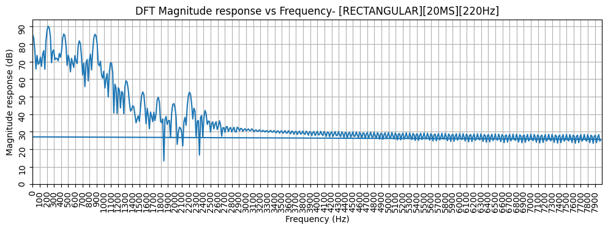

```python
samples=int(0.020*16000)
win=out220[10*samples:11*samples]
dft=np.fft.fft(win,1024)
freq=np.fft.fftfreq(dft.shape[-1],0.0000625)

#scaling axes (Y axis in decibel and x axis using sampling frequency)
plt.plot(freq,20*np.log10(np.abs(dft)))
#labelling graph
plt.xlabel('Frequency (Hz)')
plt.ylabel('Magnitude response (dB)')
plt.title('DFT Magnitude response vs Frequency- [RECTANGULAR][20MS][220Hz]')
plt.xlim(0,8000)
plt.xticks(np.arange(0,8000,100),rotation='vertical')
plt.yticks(np.arange(0,100,10),rotation='vertical')
plt.grid("True")
```

40ms

--120Hz

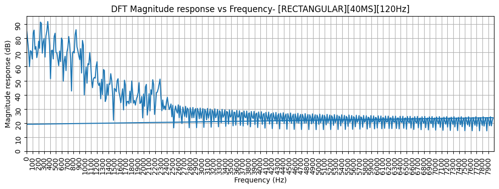

```python
samples=int(0.040*16000)
win=out120[10*samples:11*samples]
dft=np.fft.fft(win,1024)
freq=np.fft.fftfreq(dft.shape[-1],0.0000625)

#scaling axes (Y axis in decibel and x axis using sampling frequency)
plt.plot(freq,20*np.log10(np.abs(dft)))
#labelling graph
plt.xlabel('Frequency (Hz)')
plt.ylabel('Magnitude response (dB)')
plt.title('DFT Magnitude response vs Frequency- [RECTANGULAR][40MS][120Hz]')
plt.xlim(0,8000)
plt.xticks(np.arange(0,8000,100),rotation='vertical')
plt.yticks(np.arange(0,100,10),rotation='vertical')
plt.grid("True")
```

--220Hz

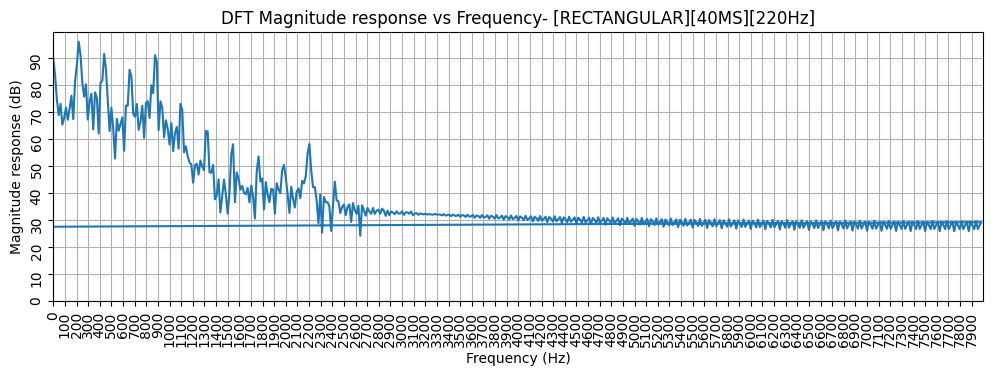

```python
samples=int(0.040*16000)
win=out220[10*samples:11*samples]
dft=np.fft.fft(win,1024)
freq=np.fft.fftfreq(dft.shape[-1],0.0000625)

#scaling axes (Y axis in decibel and x axis using sampling frequency)
plt.plot(freq,20*np.log10(np.abs(dft)))
#labelling graph
plt.xlabel('Frequency (Hz)')
plt.ylabel('Magnitude response (dB)')
plt.title('DFT Magnitude response vs Frequency- [RECTANGULAR][40MS][220Hz]')
plt.xlim(0,8000)
plt.xticks(np.arange(0,8000,100),rotation='vertical')
plt.yticks(np.arange(0,100,10),rotation='vertical')
plt.grid("True")
```

# Values and error

Error in F1,F2,F3 increases as you increase window size

Error in F0 decreases as you increase window size

Error in F1,F2,F3 is more in rectangular than Hamming

Error in F0 is more in Hamming than rectangular

1) Hamming window:

> a) 5ms:

> > (i) 120Hz:

> > > F0: Ground Truth=120Hz ; Observed Value=250Hz ; Error=130Hz

> > > F1: Ground Truth=300Hz ; Observed Value=300Hz ; Error=0Hz

> > > F2: Ground Truth=870Hz ; Observed Value=882Hz ; Error=12Hz

> > > F3: Ground Truth=2240Hz ; Observed Value=2226Hz ; Error=14Hz

> > (ii) 220Hz:

> > > F0: Ground Truth=220Hz ; Observed Value=400Hz ; Error=180Hz

> > > F1: Ground Truth=300Hz ; Observed Value=285Hz ; Error=15Hz

> > > F2: Ground Truth=870Hz ; Observed Value=883Hz ; Error=13Hz

> > > F3: Ground Truth=2240Hz ; Observed Value=2188Hz ; Error=52Hz

> b) 10ms:

> > (i) 120Hz:

> > > F0: Ground Truth=120Hz ; Observed Value=150Hz ; Error=30Hz

> > > F1: Ground Truth=300Hz ; Observed Value=255Hz ; Error=45Hz

> > > F2: Ground Truth=870Hz ; Observed Value=857Hz ; Error=13Hz

> > > F3: Ground Truth=2240Hz ; Observed Value=2293Hz ; Error=53Hz

> > (ii) 220Hz:

> > > F0: Ground Truth=220Hz ; Observed Value=290Hz ; Error=70Hz

> > > F1: Ground Truth=300Hz ; Observed Value=218Hz ; Error=82Hz

> > > F2: Ground Truth=870Hz ; Observed Value=880Hz ; Error=10Hz

> > > F3: Ground Truth=2240Hz ; Observed Value=2190Hz ; Error=50Hz

> c) 20ms:

> > (i) 120Hz

> > > F0: Ground Truth=120Hz ; Observed Value=120Hz ; Error=0Hz

> > > F2: Ground Truth=870Hz ; Observed Value=880Hz ; Error=10Hz

> > > F3: Ground Truth=2240Hz ; Observed Value=2196Hz ; Error=44Hz

> > (ii) 220Hz:

> > > F0: Ground Truth=220Hz ; Observed Value=240Hz ; Error=20Hz

> > > F1: Ground Truth=300Hz ; Observed Value=217Hz ; Error=83Hz

> > > F2: Ground Truth=870Hz ; Observed Value=838Hz ; Error=32Hz

> > > F3: Ground Truth=2240Hz ; Observed Value=2265Hz ; Error=25Hz

> d) 40ms:

> > (i) 120Hz:

> > > F0: Ground Truth=120Hz ; Observed Value=120Hz ; Error=0Hz

> > > F1: Ground Truth=300Hz ; Observed Value=213Hz ; Error=87Hz

> > > F3: Ground Truth=2240Hz ; Observed Value=2206Hz ; Error=34Hz

> > (ii) 220Hz:

> > > F0: Ground Truth=220Hz ; Observed Value=240Hz ; Error=20Hz

> > > F1: Ground Truth=300Hz ; Observed Value=213Hz ; Error=87Hz

> > > F3: Ground Truth=2240Hz ; Observed Value=2206Hz ; Error=34Hz

2) Rectangular window:

> a) 5ms:

> > (i) 120Hz:

> > > F0: Ground Truth=120Hz ; Observed Value=150Hz ; Error=30Hz

> > > F1: Ground Truth=300Hz ; Observed Value=290Hz ; Error=10Hz

> > > F2: Ground Truth=870Hz ; Observed Value=896Hz ; Error=26Hz

> > > F3: Ground Truth=2240Hz ; Observed Value=2215Hz ; Error=25Hz

> > (ii) 220Hz:

> > > F1: Ground Truth=300Hz ; Observed Value=276Hz ; Error=24Hz

> > > F2: Ground Truth=870Hz ; Observed Value=892Hz ; Error=22Hz

> > > F3: Ground Truth=2240Hz ; Observed Value=2183Hz ; Error=57Hz

> b) 10ms:

> > (i) 120Hz:

> > > F0: Ground Truth=120Hz ; Observed Value=130Hz ; Error=10Hz

> > > F1: Ground Truth=300Hz ; Observed Value=252Hz ; Error=48Hz

> > > F2: Ground Truth=870Hz ; Observed Value=846Hz ; Error=24Hz

> > > F3: Ground Truth=2240Hz ; Observed Value=2187Hz ; Error=53Hz

> > (ii) 220Hz:

> > > F0: Ground Truth=220Hz ; Observed Value=250Hz ; Error=30Hz

> > > F1: Ground Truth=300Hz ; Observed Value=215Hz ; Error=85Hz

> > > F2: Ground Truth=870Hz ; Observed Value=883Hz ; Error=13Hz

> > > F3: Ground Truth=2240Hz ; Observed Value=2188Hz ; Error=52Hz

> c) 20ms

> > (i) 120Hz

> > > F0: Ground Truth=120Hz ; Observed Value=120Hz ; Error=0Hz

> > > F2: Ground Truth=870Hz ; Observed Value=883Hz ; Error=13Hz

> > > F3: Ground Truth=2240Hz ; Observed Value=2192Hz ; Error=48Hz

> > (ii) 220Hz:

> > > F0: Ground Truth=220Hz ; Observed Value=240Hz ; Error=20Hz

> > > F1: Ground Truth=300Hz ; Observed Value=212Hz ; Error=88Hz

> > > F2: Ground Truth=870Hz ; Observed Value=842Hz ; Error=28Hz

> > > F3: Ground Truth=2240Hz ; Observed Value=2273Hz ; Error=33Hz

> d) 40ms:

> > (i) 120Hz:

> > > F0: Ground Truth=120Hz ; Observed Value=120Hz ; Error=0Hz

> > > F2: Ground Truth=870Hz ; Observed Value=827Hz ; Error=43Hz

> > > F3: Ground Truth=2240Hz ; Observed Value=2293Hz ; Error=53Hz

> > (ii) 220Hz:

> > > F0: Ground Truth=220Hz ; Observed Value=240Hz ; Error=20Hz

> > > F1: Ground Truth=300Hz ; Observed Value=202Hz ; Error=98Hz

> > > F2: Ground Truth=870Hz ; Observed Value=887Hz ; Error=17Hz

> > > F3: Ground Truth=2240Hz ; Observed Value=2261Hz ; Error=21Hz

# Comments

Smaller the window length:

> Smoother the plot

> Wider the main lobe

> Less visible harmonics

> More clear formants

> Pitch info lost

Thus on increasing window length we go from wide band to narrow band

Hamming window gives wider main lobe than rectangular window

Faster Decay from main lobe to side lobes for hamming than rect (side lobes much lower than main lobe in hamming)

Hamming window has clearer formants while rectangular window has clearer pitch info (peaks closely spaced in rectangular)

F0=>Count peak interval in large window spectrum (narrow band)

Formants which are multiples of F0 are visualized clearly

Error in F1,F2,F3 increases as you increase window size

Error in F0 decreases as you increase window size

Error in F1,F2,F3 is more in rectangular than Hamming

Error in F0 is more in Hamming than rectangular

```python
%%shell
jupyter nbconvert --to html /content/SpeechAss1_20d070009.ipynb
```

[output not shown]

[output cut: 133 more lines]

[output not shown]

[output not shown]